# Company ESG Carbon Emission Case Study

### by [Asher Chok](https://github.com/asherchok/ESG-data-analytics-study)

First, we import the excel sheet data from file directory with pandas. We replace "Missing" values in the dataframe with NaN in the `.read_excel()` argument.

```python
import pandas as pd

df = pd.read_excel('ESG_data.xlsx', na_values=["Missing"])
print(df)
```

```
              ISIN  GICS Code  Revenue  Market Cap_y  Total Assets      PPE  \
0     GB00BGXQNP29       40.0 -8958.39  5.171820e+03     293132.51    61.18
1     GB0007669376       40.0 -3597.24  6.328330e+03     120866.49    36.33
2     GB00BKFB1C65       40.0 -2867.75  4.002557e+09     274998.77  1614.92
3     GB00BDCXV269       40.0 -2300.34  2.763230e+03      83855.93    21.67
4     SE0013256682       40.0 -1528.29  6.573160e+03       8339.77     6.08
...            ...        ...      ...           ...           ...      ...
9769  US8334451098       45.0      NaN  7.403264e+10           NaN      NaN
9770  US89457R1014       40.0      NaN  5.447911e+08           NaN      NaN
9771  US92243G1085       35.0      NaN  1.924414e+09           NaN      NaN
9772  US92347D1000       40.0      NaN  1.637738e+08           NaN      NaN
9773  ZAE000282356       40.0      NaN  1.302388e+10           NaN      NaN

      Net Fixed Assets  Operating Expense   COGS_y  employee_count  \
0                61.18             1507.31     NaN             NaN
```

[output cut: 38 more lines]

We check the number of columns, the non-null count, the dtype each column, and the shape of the dataframe with `.info()` and with `.shape()`.

```python
df.info()
df.shape
```

```
<class 'pandas.core.frame.DataFrame'>
RangeIndex: 9774 entries, 0 to 9773
Data columns (total 15 columns):
 #   Column                   Non-Null Count  Dtype
---  ------                   --------------  -----
 0   ISIN                     9767 non-null   object
 1   GICS Code                9732 non-null   float64
 2   Revenue                  9656 non-null   object
 3   Market Cap_y             9708 non-null   float64
 4   Total Assets             9685 non-null   float64
 5   PPE                      8601 non-null   float64
 6   Net Fixed Assets         9594 non-null   float64
 7   Operating Expense        9640 non-null   float64
 8   COGS_y                   6765 non-null   float64
 9   employee_count           3904 non-null   float64
 10  EPA FLIGHT               305 non-null    float64
 11  TOTAL_GHG_CO2_EMISSIONS  3013 non-null   float64
 12  ENERGY_CONSUMPTION       2701 non-null   float64
 13  Unnamed: 13              0 non-null      float64
 14  Unnamed: 14              0 non-null      float64
dtypes: float64(13), object(2)
memory usage: 1.1+ MB
```

```
(9774, 15)
```

From the output above, two unnamed columns can be dropped from the data frame. Since ISIN is merely for identification purpose, it is also dropped out of the dataframe.

```python
df = df.drop(columns=['Unnamed: 13', 'Unnamed: 14', 'ISIN'])
```

To get a visualization of the data, we plot a histogram with the dataframe rows with no missing values. Since there are no NaN values for this dataframe (`df_nona`), we can convert the dtype of Revenue to float right away.

```
<class 'pandas.core.frame.DataFrame'>
Int64Index: 74 entries, 3613 to 9641
Data columns (total 12 columns):
 #   Column                   Non-Null Count  Dtype
---  ------                   --------------  -----
 0   GICS Code                74 non-null     float64
 1   Revenue                  74 non-null     object
 2   Market Cap_y             74 non-null     float64
 3   Total Assets             74 non-null     float64
 4   PPE                      74 non-null     float64
 5   Net Fixed Assets         74 non-null     float64
 6   Operating Expense        74 non-null     float64
 7   COGS_y                   74 non-null     float64
 8   employee_count           74 non-null     float64
 9   EPA FLIGHT               74 non-null     float64
 10  TOTAL_GHG_CO2_EMISSIONS  74 non-null     float64
 11  ENERGY_CONSUMPTION       74 non-null     float64
dtypes: float64(11), object(1)
memory usage: 7.5+ KB
```

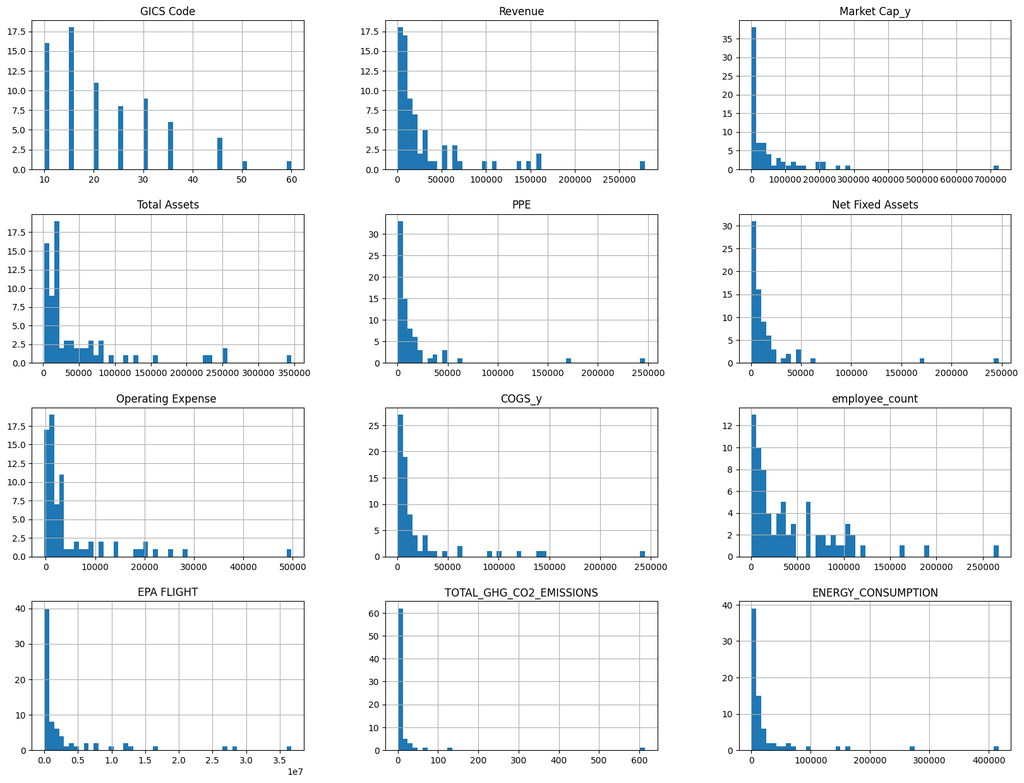

```python
df_nona = df.dropna()
df_nona.info()
df_nona['Revenue'] = df_nona['Revenue'].astype(float)

%matplotlib inline
import matplotlib.pyplot as plt
df_nona.hist(bins=50, figsize=(20,15))
plt.show()
```

From the histograms above, we see that there is a trend of high frequency of the bin ranges of each data close to 0 where most of the bar plots share similar characterics of an exponential decay curve. `GICS Code`, `Total Assets`, and `Operating Expense` have a rise in frequency across the x-axis which is similar to a heavily skewed distribution curve. However, since this data is obtained from the data frame with no NaN values (`df_nona`), we cannot generalize the characteristics observed here to the entire data frame with the smaller 74 non-null data frame.

At this point, data cleaning is not yet finished as there are many blank values in the dataframe which needs to be replaced with NaN values.

```python
import numpy as np
df = df.replace(r'^\s*$', np.nan, regex=True)
print(df)
```

```
      GICS Code  Revenue  Market Cap_y  Total Assets      PPE  \
0          40.0 -8958.39  5.171820e+03     293132.51    61.18
1          40.0 -3597.24  6.328330e+03     120866.49    36.33
2          40.0 -2867.75  4.002557e+09     274998.77  1614.92
3          40.0 -2300.34  2.763230e+03      83855.93    21.67
4          40.0 -1528.29  6.573160e+03       8339.77     6.08
...         ...      ...           ...           ...      ...
9769       45.0      NaN  7.403264e+10           NaN      NaN
9770       40.0      NaN  5.447911e+08           NaN      NaN
9771       35.0      NaN  1.924414e+09           NaN      NaN
9772       40.0      NaN  1.637738e+08           NaN      NaN
9773       40.0      NaN  1.302388e+10           NaN      NaN

      Net Fixed Assets  Operating Expense   COGS_y  employee_count  \
0                61.18             1507.31     NaN             NaN
```

[output cut: 25 more lines]

We can check the dtype of the dataframe with the following syntax.

```python
df.dtypes
```

```
GICS Code                  float64
Revenue                     object
Market Cap_y               float64
Total Assets               float64
PPE                        float64
Net Fixed Assets           float64
Operating Expense          float64
COGS_y                     float64
employee_count             float64
EPA FLIGHT                 float64
TOTAL_GHG_CO2_EMISSIONS    float64
ENERGY_CONSUMPTION         float64
dtype: object
```

Revenue column is full of float values, but the column cannot be converted to float64 from object immediately. Therefore. we re-check to see if there are any blanks or NaN's in Revenue.

```python
print((df['Revenue'].values == '').sum())
print((df['Revenue'].values == 'NaN').sum())
print((df['Revenue'].values == '0').sum())
```

```
0
0
0
```

When attempting to convert the data column with `.astype()`, the compiler gives the following two error when trying to convert Revenue from object to float:

```
ValueError: could not convert string to float: '#N/A Invalid Security'
ValueError: could not convert string to float: '#N/A Field Not Applicable'
```

Therefore, we need to modify the cells containing the strings above to NaN.

```python
df = df.replace('#N/A Invalid Security', np.nan)
df = df.replace('#N/A Field Not Applicable', np.nan)
```

```python
df['Revenue'] = df['Revenue'].astype(float)
```

Check again dtypes to ensure Revenue is now float instead of object:

```python
df.dtypes
```

```
GICS Code                  float64
Revenue                    float64
Market Cap_y               float64
Total Assets               float64
PPE                        float64
Net Fixed Assets           float64
Operating Expense          float64
COGS_y                     float64
employee_count             float64
EPA FLIGHT                 float64
TOTAL_GHG_CO2_EMISSIONS    float64
ENERGY_CONSUMPTION         float64
dtype: object
```

Which is now all float values. Check all the NaN values for each of the dataframe column:

```python
df.isnull().sum()
```

```
GICS Code                    42
Revenue                     123
Market Cap_y                 66
Total Assets                 89
PPE                        1173
Net Fixed Assets            180
Operating Expense           134
COGS_y                     3009
employee_count             5870
EPA FLIGHT                 9469
TOTAL_GHG_CO2_EMISSIONS    6761
ENERGY_CONSUMPTION         7073
dtype: int64
```

The histogram plotted earlier doesn't tell the full story of the behavior in the dataframe. Therefore, we need to plot a correlation heatmap figure to check the relationship for the variables to each other. To make the correlation plot easier to look at, the upper triangle of the diagonal table was omitted since variable correlation values are symmetrical across the diagonal.

```python
labels = df.columns.values.tolist()
rs = np.random.RandomState(0)
pd.DataFrame(rs.rand(12, 12), index = labels,
                  columns = labels)
corr = df.corr()
#show correlation heatmap plot with 2 digit precision
corr.style.background_gradient(cmap='coolwarm').set_precision(2)

#code to mask upper half of the correlational matrix
mask = np.zeros_like(corr, dtype=bool)
mask[np.triu_indices_from(mask)] = True
corr[mask] = np.nan
(corr
 .style
 .background_gradient(cmap='coolwarm', axis=None, vmin=-1, vmax=1)
 .highlight_null(color='#f1f1f1')  # Color NaNs grey
 .set_precision(2))
```

|  | GICS Code | Revenue | Market Cap_y | Total Assets | PPE | Net Fixed Assets | Operating Expense | COGS_y | employee_count | EPA FLIGHT | TOTAL_GHG_CO2_EMISSIONS | ENERGY_CONSUMPTION |
| --- | --- | --- | --- | --- | --- | --- | --- | --- | --- | --- | --- | --- |
| GICS Code | nan | nan | nan | nan | nan | nan | nan | nan | nan | nan | nan | nan |
| Revenue | -0.07 | nan | nan | nan | nan | nan | nan | nan | nan | nan | nan | nan |
| Market Cap_y | -0.01 | 0.10 | nan | nan | nan | nan | nan | nan | nan | nan | nan | nan |
| Total Assets | 0.05 | 0.43 | 0.01 | nan | nan | nan | nan | nan | nan | nan | nan | nan |
| PPE | -0.08 | 0.76 | 0.15 | 0.23 | nan | nan | nan | nan | nan | nan | nan | nan |
| Net Fixed Assets | -0.02 | 0.73 | 0.13 | 0.23 | 0.98 | nan | nan | nan | nan | nan | nan | nan |
| Operating Expense | -0.05 | 0.70 | 0.09 | 0.27 | 0.61 | 0.61 | nan | nan | nan | nan | nan | nan |
| COGS_y | -0.07 | 0.98 | 0.00 | 0.71 | 0.74 | 0.69 | 0.69 | nan | nan | nan | nan | nan |
| employee_count | -0.08 | 0.69 | 0.00 | 0.31 | 0.42 | 0.40 | 0.47 | 0.63 | nan | nan | nan | nan |
| EPA FLIGHT | 0.23 | 0.21 | -0.02 | 0.19 | 0.52 | 0.44 | 0.12 | 0.20 | -0.01 | nan | nan | nan |
| TOTAL_GHG_CO2_EMISSIONS | -0.02 | 0.23 | 0.05 | 0.02 | 0.41 | 0.39 | 0.26 | 0.16 | 0.04 | 0.25 | nan | nan |
| ENERGY_CONSUMPTION | 0.02 | 0.06 | 0.01 | 0.00 | 0.11 | 0.11 | 0.06 | 0.04 | 0.07 | 0.82 | 0.16 | nan |

From the heatmap above, we observe that there are variables having higher correlation values for the TOTAL_GHG_CO2_EMISSIONS column. In particular, PPE column has the highest correlational value, and Net Fixed Assets being the second highest, then operating expense as the third. This heatmap will be used to compare with the test results later.

## MICE Imputation Method using Linear Regression

Multiple Imputation by Chained Equations (MICE) first calculates the mean of every column where there is a missing value and uses the mean value as a placeholder. Then it runs a series of regression models (chained equations) to impute each missing value sequentially. Like in any regression model, MICE uses a feature matrix and target variable to train, and in this case, the target variable is the column with missing values. MICE predicts and updates missing values on target columns. Iteratively, MICE repeats this process several times by constantly changing the placeholder variables with the predictions from the previous iteration. In the end, it reaches a robust estimation.

With this approach, we predict the Missing values of all variables using the MICE imputation method under the assumption that tthe missing data are Missing At Random (MAR).

```python
from sklearn.experimental import enable_iterative_imputer
from sklearn.impute import IterativeImputer
from sklearn.linear_model import LinearRegression

lr = LinearRegression()
imp = IterativeImputer(estimator = lr,missing_values = np.nan, max_iter = 10, verbose = 2, imputation_order = 'roman',random_state = 0)
mice_data = imp.fit_transform(df)
```

```
[IterativeImputer] Completing matrix with shape (9774, 12)
[IterativeImputer] Ending imputation round 1/10, elapsed time 0.03
[IterativeImputer] Change: 31814692106.656265, scaled tolerance: 6920000000.0
[IterativeImputer] Ending imputation round 2/10, elapsed time 0.06
[IterativeImputer] Change: 756240174.2290999, scaled tolerance: 6920000000.0
[IterativeImputer] Early stopping criterion reached.
```

From the imputed data, we make a new dataframe but with the columns from the original dataframe.

```python
mice_df = pd.DataFrame(mice_data,columns=df.columns)
```

First we do a scatterplot of the original dataframe.

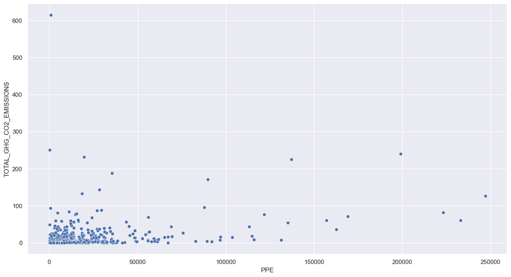

```python
import seaborn as sns
sns.set(rc={'figure.figsize':(15.7,8.27)})
sns.scatterplot(data=df,x='PPE',y='TOTAL_GHG_CO2_EMISSIONS')
```

Then we apply the imputed `TOTAL_GHG_CO2_EMISSIONS` values to the scatterplot.

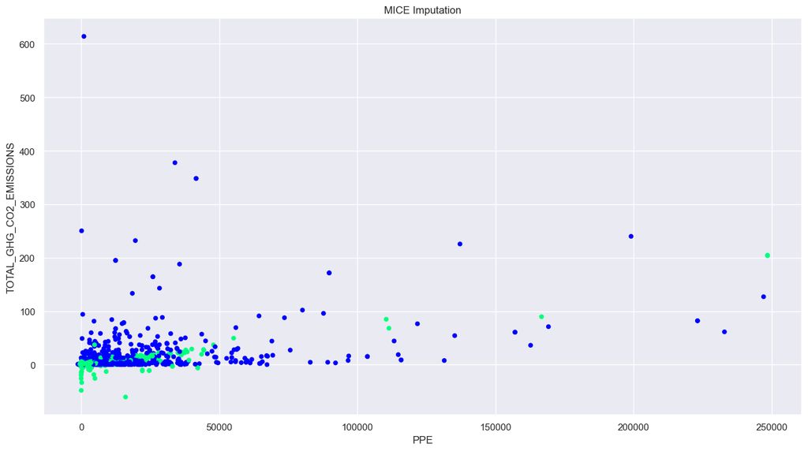

```python
null_values = df['TOTAL_GHG_CO2_EMISSIONS'].isnull()
fig = mice_df.plot(x='PPE', y='TOTAL_GHG_CO2_EMISSIONS', kind='scatter', c=null_values, cmap='winter', title='MICE Imputation', colorbar=False)
```

From the second scatterplot, there exist negative values of TOTAL_GHG_CO2_EMISSIONS. To confirm our results, we check on the null count of 'TOTAL_GHG_CO2_EMISSIONS' on the original dataframe:

```python
(df['TOTAL_GHG_CO2_EMISSIONS'] < 0).sum().sum()
```

```
0
```

There were no companies with negative CO2 emissions from the original dataframe whereas out initial attempt had too many negative values, which means that the initial approach to this problem is not correct. For our second attempt, we will first impute the missing values of x variables. Then after that we apply linear regression to predict the values of y variable that is `TOTAL_GHG_CO2_EMISSIONS`.

## Second attempt

First, we impute x variable from the feature column of dataframe.

```python
x = df.drop("TOTAL_GHG_CO2_EMISSIONS", axis = 1)
```

```python
mice_x = imp.fit_transform(x)
```

```
[IterativeImputer] Completing matrix with shape (9774, 11)
[IterativeImputer] Ending imputation round 1/10, elapsed time 0.04
[IterativeImputer] Change: 31977349403.33261, scaled tolerance: 6920000000.0
[IterativeImputer] Ending imputation round 2/10, elapsed time 0.06
[IterativeImputer] Change: 767634806.3360388, scaled tolerance: 6920000000.0
[IterativeImputer] Early stopping criterion reached.
```

Then we make another dataframe `mice2_df` with the imputed feature column variable x and add the original y variable column from the original dataframe `df` for the linear regression approach later.

```python
mice2_df = pd.DataFrame(mice_x,columns=x.columns)
mice2_df['TOTAL_GHG_CO2_EMISSIONS'] =df['TOTAL_GHG_CO2_EMISSIONS']
```

Check the null count of `mice2_df` to ensure the new dataframe has no null values for all columns except `TOTAL_GHG_CO2_EMISSIONS`:

```python
mice2_df.isnull().sum()
```

```
GICS Code                     0
Revenue                       0
Market Cap_y                  0
Total Assets                  0
PPE                           0
Net Fixed Assets              0
Operating Expense             0
COGS_y                        0
employee_count                0
EPA FLIGHT                    0
ENERGY_CONSUMPTION            0
TOTAL_GHG_CO2_EMISSIONS    6761
dtype: int64
```

To ensure this new dataframe shares the same characteristics with the original dataframe, we check the correlation table of the two:

```python
labels = df.columns.values.tolist()
rs = np.random.RandomState(0)
pd.DataFrame(rs.rand(12, 12), index = labels,
                  columns = labels)
corr = df.corr()
#show correlation heatmap plot with 2 digit precision
corr.style.background_gradient(cmap='coolwarm').set_precision(2)

#code to mask upper half of the correlational matrix
mask = np.zeros_like(corr, dtype=bool)
mask[np.triu_indices_from(mask)] = True
corr[mask] = np.nan
(corr
 .style
 .background_gradient(cmap='coolwarm', axis=None, vmin=-1, vmax=1)
 .highlight_null(color='#f1f1f1')  # Color NaNs grey
 .set_precision(2))
```

|  | GICS Code | Revenue | Market Cap_y | Total Assets | PPE | Net Fixed Assets | Operating Expense | COGS_y | employee_count | EPA FLIGHT | TOTAL_GHG_CO2_EMISSIONS | ENERGY_CONSUMPTION |
| --- | --- | --- | --- | --- | --- | --- | --- | --- | --- | --- | --- | --- |
| GICS Code | nan | nan | nan | nan | nan | nan | nan | nan | nan | nan | nan | nan |
| Revenue | -0.07 | nan | nan | nan | nan | nan | nan | nan | nan | nan | nan | nan |
| Market Cap_y | -0.01 | 0.10 | nan | nan | nan | nan | nan | nan | nan | nan | nan | nan |
| Total Assets | 0.05 | 0.43 | 0.01 | nan | nan | nan | nan | nan | nan | nan | nan | nan |
| PPE | -0.08 | 0.76 | 0.15 | 0.23 | nan | nan | nan | nan | nan | nan | nan | nan |
| Net Fixed Assets | -0.02 | 0.73 | 0.13 | 0.23 | 0.98 | nan | nan | nan | nan | nan | nan | nan |
| Operating Expense | -0.05 | 0.70 | 0.09 | 0.27 | 0.61 | 0.61 | nan | nan | nan | nan | nan | nan |
| COGS_y | -0.07 | 0.98 | 0.00 | 0.71 | 0.74 | 0.69 | 0.69 | nan | nan | nan | nan | nan |
| employee_count | -0.08 | 0.69 | 0.00 | 0.31 | 0.42 | 0.40 | 0.47 | 0.63 | nan | nan | nan | nan |
| EPA FLIGHT | 0.23 | 0.21 | -0.02 | 0.19 | 0.52 | 0.44 | 0.12 | 0.20 | -0.01 | nan | nan | nan |
| TOTAL_GHG_CO2_EMISSIONS | -0.02 | 0.23 | 0.05 | 0.02 | 0.41 | 0.39 | 0.26 | 0.16 | 0.04 | 0.25 | nan | nan |
| ENERGY_CONSUMPTION | 0.02 | 0.06 | 0.01 | 0.00 | 0.11 | 0.11 | 0.06 | 0.04 | 0.07 | 0.82 | 0.16 | nan |

```python
labels = mice2_df.columns.values.tolist()
rs = np.random.RandomState(0)
pd.DataFrame(rs.rand(12, 12), index = labels,
                  columns = labels)
corr = mice2_df.corr()
#show correlation heatmap plot with 2 digit precision
corr.style.background_gradient(cmap='coolwarm').set_precision(2)

#code to mask upper half of the correlational matrix
mask = np.zeros_like(corr, dtype=bool)
mask[np.triu_indices_from(mask)] = True
corr[mask] = np.nan
(corr
 .style
 .background_gradient(cmap='coolwarm', axis=None, vmin=-1, vmax=1)
 .highlight_null(color='#f1f1f1')  # Color NaNs grey
 .set_precision(2))
```

|  | GICS Code | Revenue | Market Cap_y | Total Assets | PPE | Net Fixed Assets | Operating Expense | COGS_y | employee_count | EPA FLIGHT | ENERGY_CONSUMPTION | TOTAL_GHG_CO2_EMISSIONS |
| --- | --- | --- | --- | --- | --- | --- | --- | --- | --- | --- | --- | --- |
| GICS Code | nan | nan | nan | nan | nan | nan | nan | nan | nan | nan | nan | nan |
| Revenue | -0.07 | nan | nan | nan | nan | nan | nan | nan | nan | nan | nan | nan |
| Market Cap_y | -0.01 | 0.10 | nan | nan | nan | nan | nan | nan | nan | nan | nan | nan |
| Total Assets | 0.05 | 0.43 | 0.01 | nan | nan | nan | nan | nan | nan | nan | nan | nan |
| PPE | -0.05 | 0.73 | 0.13 | 0.23 | nan | nan | nan | nan | nan | nan | nan | nan |
| Net Fixed Assets | -0.02 | 0.73 | 0.13 | 0.23 | 0.98 | nan | nan | nan | nan | nan | nan | nan |
| Operating Expense | -0.05 | 0.70 | 0.09 | 0.27 | 0.59 | 0.61 | nan | nan | nan | nan | nan | nan |
| COGS_y | -0.07 | 0.78 | 0.06 | 0.28 | 0.50 | 0.48 | 0.10 | nan | nan | nan | nan | nan |
| employee_count | -0.09 | 0.74 | 0.05 | 0.35 | 0.44 | 0.44 | 0.52 | 0.59 | nan | nan | nan | nan |
| EPA FLIGHT | 0.05 | -0.09 | -0.93 | -0.00 | -0.09 | -0.10 | -0.08 | -0.05 | -0.12 | nan | nan | nan |
| ENERGY_CONSUMPTION | 0.01 | 0.05 | 0.00 | 0.00 | 0.11 | 0.11 | 0.06 | 0.03 | -0.17 | 0.36 | nan | nan |
| TOTAL_GHG_CO2_EMISSIONS | -0.02 | 0.23 | 0.05 | 0.02 | 0.38 | 0.39 | 0.26 | 0.10 | 0.08 | 0.04 | 0.15 | nan |

Now we prepare the dataset for linear regression. We choose to normalize the values to [0,1] with `MinMaxScaler`:

```python
from sklearn.preprocessing import MinMaxScaler
scaler = MinMaxScaler()
# transform data
scaled = scaler.fit_transform(mice2_df)
print(scaled)
```

```
[[0.6        0.         0.00319065 ... 0.61818137 0.01918411 0.        ]
 [0.6        0.01052648 0.00319065 ... 0.61793822 0.01915608 0.        ]
 [0.6        0.01195881 0.00376721 ... 0.61775791 0.01918005        nan]
 ...
 [0.5        0.02889852 0.00346785 ... 0.61730639 0.01914965        nan]
 [0.6        0.02856449 0.00321424 ... 0.61761223 0.0191561         nan]
 [0.6        0.02875787 0.00506671 ... 0.61646175 0.01915328        nan]]
```

We then make a new dataframe `scaled` with the normalized `mice2_df` dataframe.

```python
scaled = pd.DataFrame(scaled,columns=mice2_df.columns)
```

From the second correlation heatmap, we see that the four variables have significant correlation value against `TOTAL_GHG_CO2_EMISSIONS`: `Revenue`, `PPE`, `Net Fixed Assets`, and `Operating Expense`. Therefore, we will use them to predict `TOTAL_GHG_CO2_EMISSIONS`.

```python
#Test set with 6761 'TOTAL_GHG_CO2_EMISSIONS' null values
test_df = scaled[mice2_df['TOTAL_GHG_CO2_EMISSIONS'].isnull()]
x_test = test_df[['Revenue', 'PPE','Net Fixed Assets', 'Operating Expense ']]

#Training set without the 'TOTAL_GHG_CO2_EMISSIONS' null values
train_df = scaled[mice2_df['TOTAL_GHG_CO2_EMISSIONS'].isnull()==False]
x_train= train_df[['Revenue', 'PPE','Net Fixed Assets', 'Operating Expense ']]
y_train = train_df['TOTAL_GHG_CO2_EMISSIONS']
```

We check for the shape of the test set and training set to ensure that we get the dimensions correct before starting the linear regression fit.

```python
print('x train: ',x_train.shape)
print('y train: ',y_train.shape)
print('x test: ',x_test.shape)
```

```
x train:  (3013, 4)
y train:  (3013,)
x test:  (6761, 4)
```

```python
from sklearn.linear_model import LinearRegression
lr = LinearRegression()
model = lr.fit(x_train, y_train)

# predicting the test set results
y_pred = model.predict(x_test)
```

We add the predicted test set result to the final table.

```python
test_df['TOTAL_GHG_CO2_EMISSIONS'] = y_pred
```

```python
final_df = train_df.append(test_df, ignore_index=True)
final_df.shape
```

```
(9774, 12)
```

We then try to compare the values of TOTAL_GHG_CO2_EMISSIONS before and after prediction with seaborn's scatterplot diagrams:

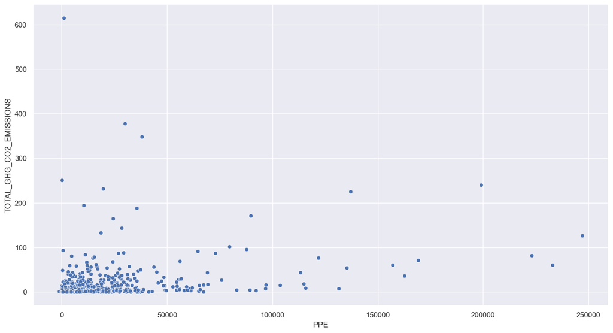

```python
sns.scatterplot(data=mice2_df,x='PPE',y='TOTAL_GHG_CO2_EMISSIONS')
```

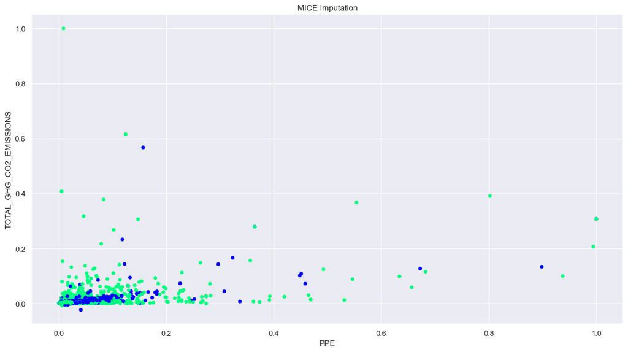

```python
null_values = mice2_df['TOTAL_GHG_CO2_EMISSIONS'].isnull()
fig = final_df.plot(x='PPE', y='TOTAL_GHG_CO2_EMISSIONS', kind='scatter', c=null_values, cmap='winter', title='MICE Imputation', colorbar=False)
```